# Assessing the drift in the pace starting library

Kian Bigovic VIlli

2024-09-20

Load the required packages to do the analysis

Load the sanger sequencing data

```r
# List the files that have the ab1 files extension
ab_files <- list.files(pattern = '..ab1',
                       full.names = T,
                       path = 'raw_data/')

# Load them into memory as a list for easy operation
ab_data_list <- lapply(ab_files, readsangerseq)

# Set names for the list according to filenames
names(ab_data_list) <- gsub(pattern = "\\.\\.ab1", replacement = '', x = ab_files)

# Define the nucleotide order in the was sangerseqR defines it
nucleotide_order <- c('A','C','G','T')
```

# Chromatograms

For starters lets see how do the chromatograms look for the data at hand.

```r
# Call the sangerseqR function that plots out the chromatograms, export as .pdfs as they are toon large to plot in an RMarkdown
# Create the directory for the chromatograms
dir.create('chromatograms')
# Define the chromatogram filenames
chromatogram_files <- gsub(pattern = "\\.\\.ab1", replacement = '.pdf', x = basename(ab_files))

mapply(ab_data_list, chromatogram_files, FUN = function(current_ab, outfile){

  sangerseqR::chromatogram(obj = current_ab,
                           width = 100,
                           height = 3,
                           showcalls = "both",
                           filename = paste(getwd(),'/chromatograms/',outfile, sep = ''))
})
```

```
## Chromatogram saved to /Users/kian/Desktop/idec/11092024_SIAH1_drift_sanger/chromatograms/siah 1 p clone 3_oLS-670.pdf in the current working directory
```

```
## Chromatogram saved to /Users/kian/Desktop/idec/11092024_SIAH1_drift_sanger/chromatograms/SIAH1 drift - Passage 2 01.09._oLS-670.pdf in the current working directory
```

```
## Chromatogram saved to /Users/kian/Desktop/idec/11092024_SIAH1_drift_sanger/chromatograms/SIAH1 drift - Passage 4 03.09._oLS-670.pdf in the current working directory
```

```
## Chromatogram saved to /Users/kian/Desktop/idec/11092024_SIAH1_drift_sanger/chromatograms/SIAH1 drift - Passage 6 07.09._oLS-670.pdf in the current working directory
```

```
## Chromatogram saved to /Users/kian/Desktop/idec/11092024_SIAH1_drift_sanger/chromatograms/SIAH1 drift - Passage 8 11.09._oLS-670.pdf in the current working directory
```

```
## $`raw_data//siah 1 p clone 3_oLS-670`
## NULL
##
## $`raw_data//SIAH1 drift - Passage 2 01.09._oLS-670`
## NULL
##
## $`raw_data//SIAH1 drift - Passage 4 03.09._oLS-670`
## NULL
##
## $`raw_data//SIAH1 drift - Passage 6 07.09._oLS-670`
## NULL
##
## $`raw_data//SIAH1 drift - Passage 8 11.09._oLS-670`
## NULL
```

Visually we can see that later passages have some changes.

# Number of uncalled positions

For starters we can recover the number of positions that couldn’t be called by the base calling software, we will exclude the first 50 and last 100-150ish positions

```r
# Go over the samples and count the number of positions called as N, preliminary idea, as a proxy of positions that can't be called
lapply(ab_data_list, FUN = function(x){letterFrequency(x@primarySeq[c(50:1100)], letters = c('A','T','G','C','N'))})
```

```
## $`raw_data//siah 1 p clone 3_oLS-670`
##   A   T   G   C   N
## 222 263 294 272   0
##
## $`raw_data//SIAH1 drift - Passage 2 01.09._oLS-670`
##   A   T   G   C   N
## 221 264 294 272   0
##
## $`raw_data//SIAH1 drift - Passage 4 03.09._oLS-670`
##   A   T   G   C   N
## 221 262 296 272   0
##
## $`raw_data//SIAH1 drift - Passage 6 07.09._oLS-670`
##   A   T   G   C   N
## 222 254 298 269   8
##
## $`raw_data//SIAH1 drift - Passage 8 11.09._oLS-670`
##   A   T   G   C   N
## 222 262 292 274   1
```

Yeah they all seem to be perfectly nice base called, so we need to go a bit deeper.

# The fraction of signal occupied by the called position

Next rough look is to just calculate the amount of signal that is occupied by the called base (the one with max signal) and report it.

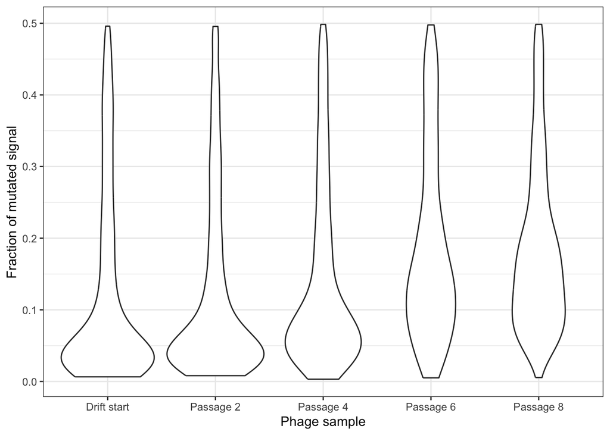

```r
largest.signal.fraction <- function(ab_object,
                                    skip_first_n = 1,
                                    last_pos = 1100){
  # Takes in an ab1 object and for each position it spits out the fraction of signal occupied by the highest signal base
  signal_df <- data.frame(ab_object@peakAmpMatrix[c(skip_first_n:last_pos),])

  # Remove the NAs
  signal_df[is.na(signal_df)] <- 0

  # Calculate the fraction
  fraction_max_at_pos <- do.call(pmax, signal_df) / rowSums(signal_df)

  return(fraction_max_at_pos)
}

# Loof the analysis across all files
fraction_at_max <- lapply(ab_data_list, largest.signal.fraction)

# Turn to a data.frame for better manipulatio
fraction_at_max_df <- data.frame(do.call(cbind, fraction_at_max))

# Name the samples
colnames(fraction_at_max_df) <- c('Drift start', 'Passage 2', 'Passage 4', 'Passage 6', 'Passage 8')

# Add the position information
fraction_at_max_df$position <- c(1:nrow(fraction_at_max_df))

# Melt into long format for plotting
fraction_at_max_long <- melt(fraction_at_max_df, id.vars = 'position')

# Standard violin plot
ggplot(fraction_at_max_long, aes(x = variable, y = 1 - value))+
  geom_violin()+
  theme_bw()+
  labs(x = 'Phage sample',
       y = 'Fraction of mutated signal')
```

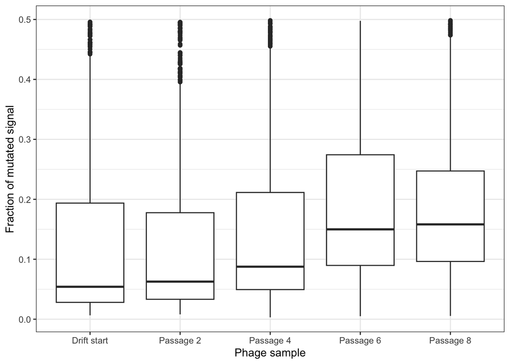

```r
# Standard box plot
ggplot(fraction_at_max_long, aes(x = variable, y = 1 - value))+
  geom_boxplot()+
  theme_bw()+
  labs(x = 'Phage sample',
       y = 'Fraction of mutated signal')
```

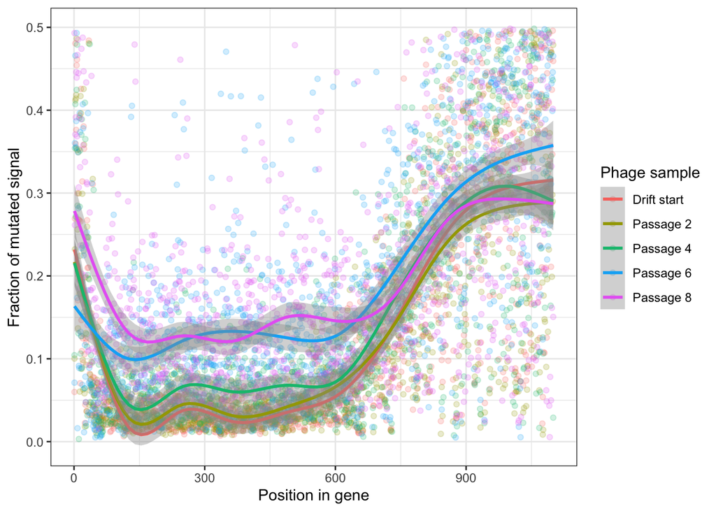

```r
# Signal across positions with a smoothing line
ggplot(fraction_at_max_long, aes(x = position, y = 1 - value, color = variable))+
  geom_point(alpha = 0.2)+
  geom_smooth(method="auto", se=TRUE, fullrange=FALSE, level=0.95, linewidth = 1)+
  theme_bw()+
  labs(x = 'Position in gene',
       y = 'Fraction of mutated signal',
       color = 'Phage sample')
```

Here we can see that: a) the first 50bp and everything after 650 bp is variable across the board, as is expected of single primer Sanger sequencing. b) that later passages have more signal coming from non-called bases

Let’s limit our final plots to the window that has has quality data (50 - 650)

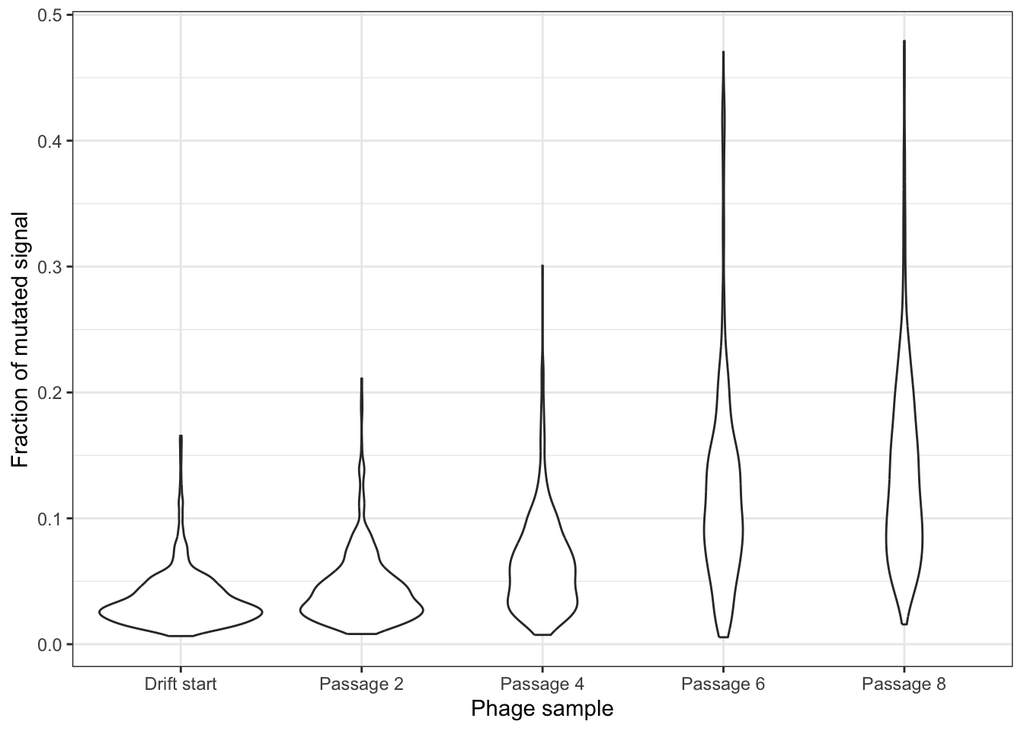

```r
# Filter only the positions that we are interested in
good_quality_fraction_at_max_long <- fraction_at_max_long%>%
  filter(position >= 50 & position < 650)
# create the output directory
dir.create('plots')

violin_plot <- ggplot(good_quality_fraction_at_max_long ,
                      aes(x = variable, y = 1 - value))+
                  geom_violin()+
                  theme_bw()+
                  labs(x = 'Phage sample',
                       y = 'Fraction of mutated signal')
violin_plot
```

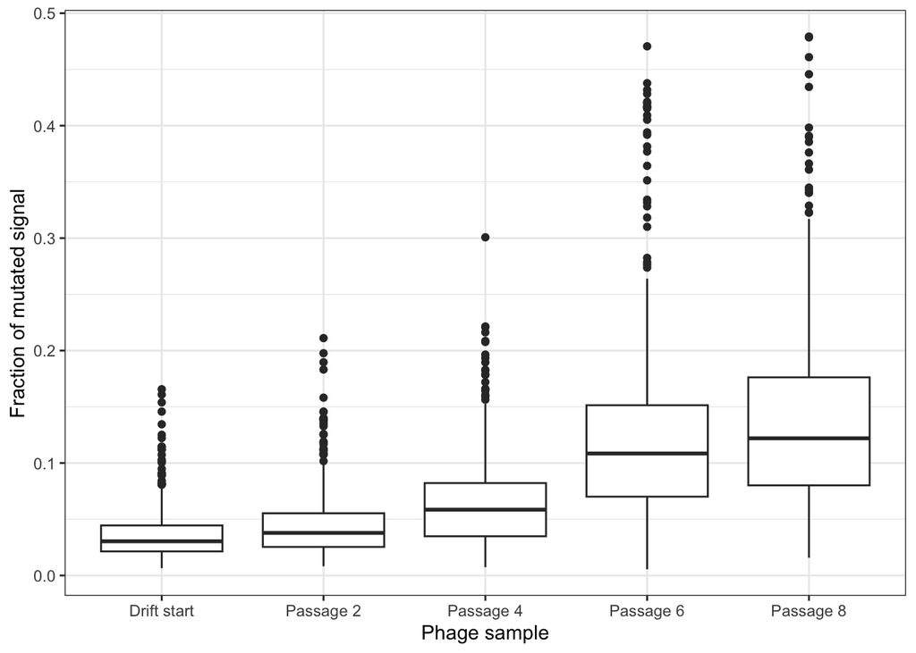

```r
# Save .pdf and .png
ggsave(plot = violin_plot,
       filename = 'Violin_plot_quality_positions.png',
       path = 'plots/')
ggsave(plot = violin_plot,
       filename = 'Violin_plot_quality_positions.pdf',
       path = 'plots/')
boxplot <- ggplot(good_quality_fraction_at_max_long ,
                  aes(x = variable, y = 1 - value))+
              geom_boxplot()+
              theme_bw()+
              labs(x = 'Phage sample',
                   y = 'Fraction of mutated signal')
boxplot
```

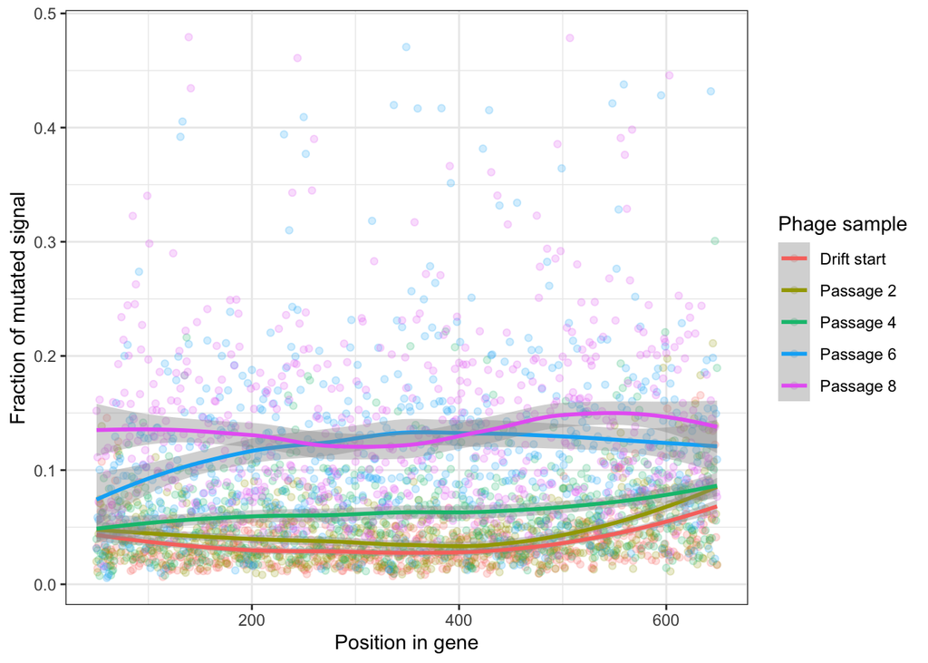

```r
# Save .pdf and .png
ggsave(plot = boxplot,
       filename = 'Boxplot_quality_positions.png',
       path = 'plots/')
ggsave(plot = boxplot,
       filename = 'Boxplot_quality_positions.pdf',
       path = 'plots/')
signal_by_pos_plot <- ggplot(good_quality_fraction_at_max_long ,
                             aes(x = position, y = 1 - value, color = variable))+
                        geom_point(alpha = 0.2)+
                        geom_smooth(method="auto",
                                    se=TRUE,
                                    fullrange=FALSE,
                                    level=0.95,
                                    linewidth = 1)+
                        theme_bw()+
                        labs(x = 'Position in gene',
                             y = 'Fraction of mutated signal',
                             color = 'Phage sample')
signal_by_pos_plot
```

```r
# Save .pdf and .png
ggsave(plot = signal_by_pos_plot,
       filename = 'Signal_per_position_plot_quality_positions.png',
       path = 'plots/')
ggsave(plot = signal_by_pos_plot,
       filename = 'Signal_per_position_plot_quality_positions.pdf',
       path = 'plots/')
```